# Workflow for the R Package csurvey

## Introduction

The **csurvey** package extends the well-known **survey** package by allowing users to impose **order constraints** on domain means (or on the systematic component for GLMs). When such constraints are reasonable (e.g., cholesterol increases with age), they can:

- Reduce variance and shorten confidence intervals
- Allow estimation and inference in small or even empty domains
- Provide one-sided hypothesis tests and a cone information criterion (CIC) for model selection

For more complete details and additional examples (including NSCG data), see the accompanying R Journal article on csurvey.

## How to use csurvey

The **csurvey** package relies on the functions in the **survey** package such as `svydesign` and `svrepdesign`, which allow users to specify the survey design. This function produces an object that contains information about the sampling design, allowing the user to specify strata, sampling weights, etc.

The **csurvey** package provides users with symbolic functions, such as `incr`, `decr`, etc, to impose ordering constraints.

## NHANES Examples

The National Health and Nutrition Examination Survey (NHANES) combines in-person interviews and physical examinations to produce a comprehensive data set from a probability sample of residents of the U.S. The data are made available to the public at this [CDC NHANES website](https://wwwn.cdc.gov/nchs/nhanes/).

The subset used in for the first two examples is derived from the 2009–2010 NHANES cycle and is provided in the `csurvey` package as the `nhdat2` data set. We consider the task of estimating the average total cholesterol level (mg/dL), originally recorded as `LBXTC` in the raw NHANES data, by age (in years), corresponding to the original variable `RIDAGEYR`. Focusing on young adults aged 21 to 45, we analyze a sample of $n = 1,933$ participants and specify the survey design using the associated weights and strata available in the data.

### 1. Domain means monotonic in one dimension

```r
library(csurvey)
data(nhdat2, package = "csurvey")
dstrat <- svydesign(ids = ~id,  strata = ~str, data = nhdat2,  weight = ~wt)
```

Then, to get the proposed constrained domain mean estimate, we use the `csvy` function in the `csurvey` package. In this function, `incr` is a symbolic function used to define that the population domain means of `chol` are increasing with respect to the predictor `age`.

```r
ans <- csvy(chol ~ incr(age), design = dstrat, n.mix = 100)
```

The `n.mix` parameter controls the number of simulations used to estimate the mixture covariance matrix, with a default of `n.mix = 100`. To speed up computation, users can set `n.mix` to be a smaller number, e.g., 10.

We can extract from `ans` the CIC value for the constrained estimator as

```r
cat("CIC (constrained):", ans$CIC, "\n")
```

```
#> CIC (constrained): 32.99313
```

and the CIC value for the unconstrained estimator as

```r
cat("CIC (unconstrained):", ans$CIC.un, "\n")
```

```
#> CIC (unconstrained): 51.65159
```

We see that for this example, the constrained estimator has a smaller CIC value and this implies it is a better fit.

The `csvy` function produces both the constrained fit and the corresponding unconstrained fit using methods from the **survey** package. A visual comparison between the two fits can be easily obtained by applying the `plot` method to the resulting `csvy` object with specifying the argument `type = "both"`.

For illustration, we display the estimated domain means along with $95\%$ confidence intervals by the following code:

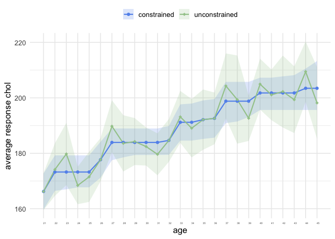

```r
plot(ans, type = "both")
```

The `confint` function can be used to extract the confidence interval for domain mean. When the response is not Gaussian, then `type="link"` produces the confidence interval for average systematic component over domains, while `type="response"` produces the confidence interval for the domain mean.

### 2. Domain means monotonic in two dimensions and unconstrained in the third dimension

For this `nhdat2` data set, the sample sizes for each of the twenty-five ages range from 54 to 99, so that none of the domains is “small.” To demonstrate `csvy` in the case of small domains, we next provide domain mean estimates and confidence intervals for $400$ domains, arranged in a grid with 25 ages (`age`), four waist-size categories (`wcat`), and four income categories (`icat`).

The domain sample sizes average only 4.8 observations, and there are 16 empty domains. The sample size for each domain can be checked by `ans$nd`. To estimate the population means we assume average cholesterol level is increasing in both age and waist size, but no ordering is imposed on income categories:

```r
set.seed(1)
ans <- csvy(chol ~ incr(age)*incr(wcat)*icat, design = dstrat)
```

To extract estimates and confidence intervals for specific domains defined by the model, the user can use the `predict` function as follows:

```r
domains <- data.frame(age = c(24, 35), wcat = c(2, 4), icat = c(2, 3))
pans <- predict(ans, newdata = domains, se.fit = TRUE)
cat("Predicted values, confidence intervals and standard errors for specified domains:\n")
```

```
#> Predicted values, confidence intervals and standard errors for specified domains:
```

```r
print (pans)
```

```
#> $fit
#> [1] 162.9599 202.0061
#>
#> $lwr
#> [1] 148.4113 183.8585
#>
#> $upp
#> [1] 177.8921 219.4409
#>
#> $se.fit
#> [1] 7.520757 9.077306
```

The `plot` function displays the domain mean estimates along with $95\%$ confidence intervals, highlighting in red the two domains specified in the `predict` function. The code to create this plot is as below. The `control` argument is used let the user adjust aesthetics of the plot.

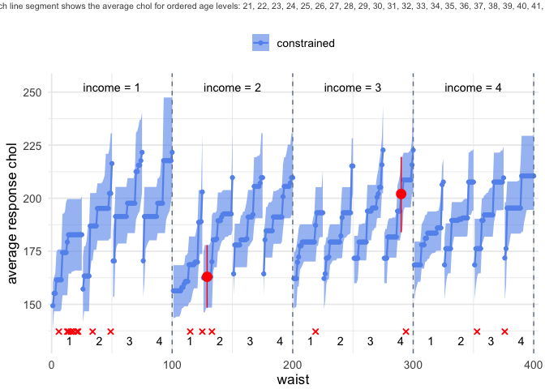

```r
ctl <- list(x1lab = "waist", x2lab = "income", subtitle.size = 8)
plot(ans, x1 = "wcat", x2 = "icat", control = ctl, domains = domains)
```

The user can visualize the unconstrained fit by specifying `type = "unconstrained"` in the `plot` function.

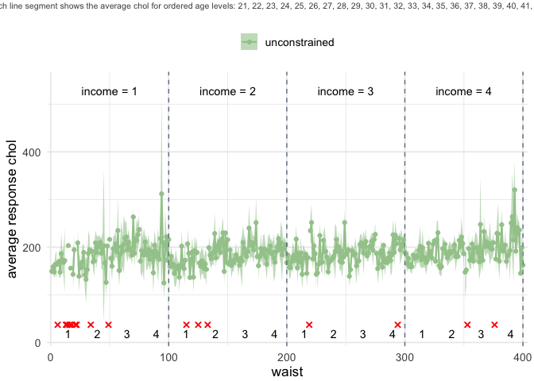

```r
plot(ans, x1 = "wcat", x2 = "icat", control = ctl, type="unconstrained")
```